# Survey Report of the Liberal Party Supporters in the University-Rosedale Riding District with Data Simulation and Analysis

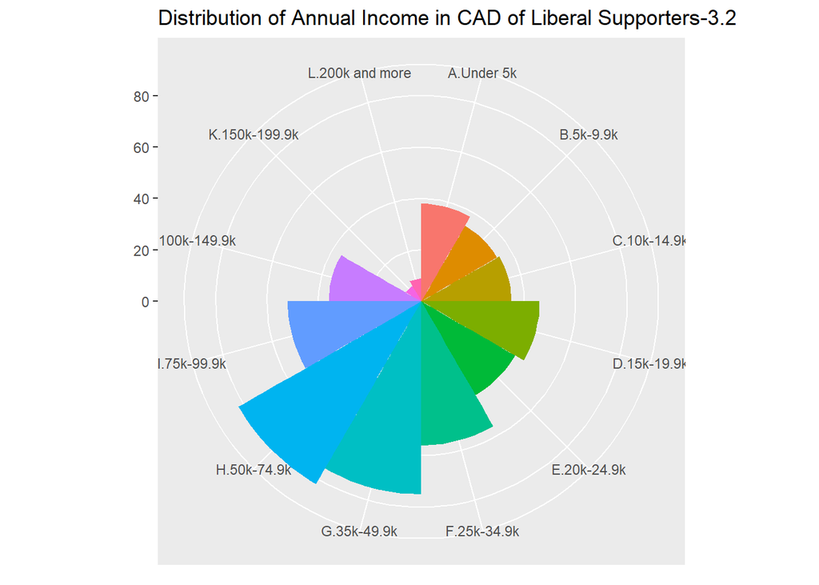

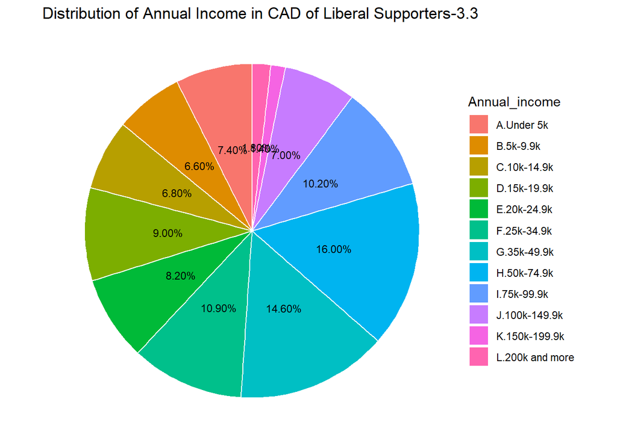

Figure 3.1-3.3 ‘Distribution of Income in CAD of Liberal Supporters’ illustrates the detailed distribution of Liberal supporters’ income ranges. Their annual income is mainly in $35,000 to $49,999 and $50,000 to $74,999, each contain 75 and 82 people respectively. The income groups $35,000 to $49,999 and $50,000 to $74,999 in Canada are representatives of the middle class and the summation of these two gropes’ proportion in total Liberals votes is 30.6%. This result states that Liberals rely mainly on the middle class’s support since they attribute to almost 1/3 of the total. On the other hand, participants who earn more than $150,000 per year occupies only 3.2% of total Liberals votes. (Although those two groups would make much more money compared to all the others, the rare quantity makes them indecisive for party election.) Therefore, if the Liberal Party wants to draw more attention in the next election, they might need to focus more on the middle class.

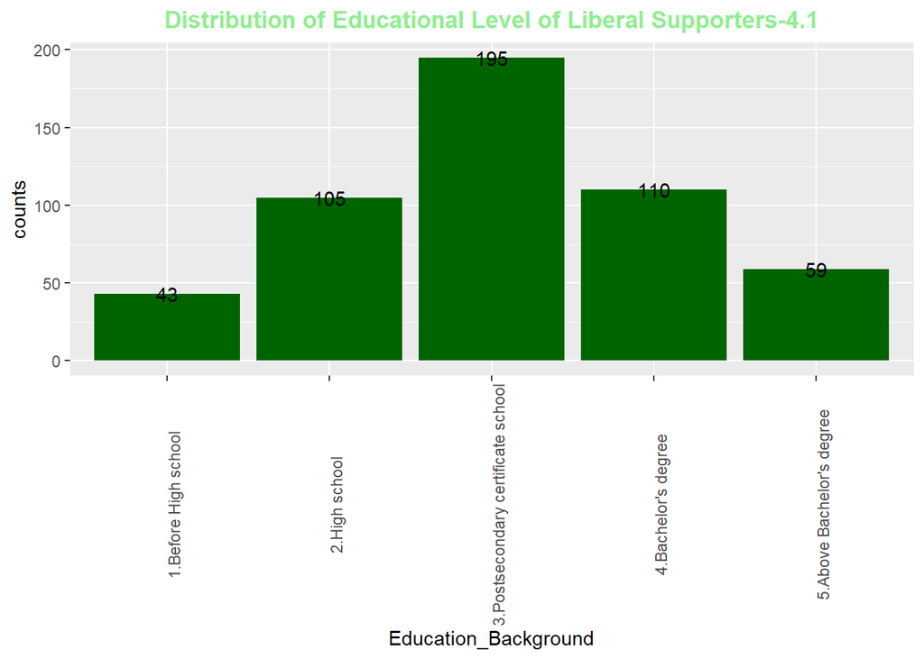

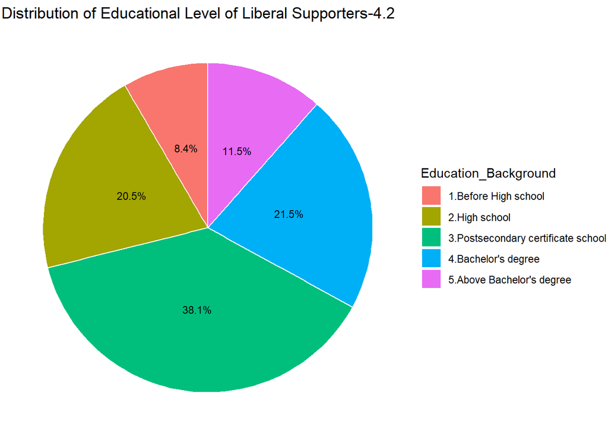

Figure 4.1-4.2 “Distribution of Educational Level of Liberal Supporters” indicates the educational backgrounds of the participants. 195 people graduated from certificated postsecondary schools, which occupies 38.1% of the total Liberals votes, accounting for the predominant proportion. Notably, according to the overall educational background of Ontario, people with a Bachelor’s degree (or higher) are only a minority compared to people who got less education. Therefore, 21.5 and 11.5 percent from the group “Bachelor’s degree” and group “Master degree or higher” respectively is considered high, attributing to a remarkable proportion of Liberals votes. This shows that the Liberal Party is more popular among the well-educated population. The reason might be Liberals policy is easier for those groups of people to understand and this feature needs to be kept by Liberals for taking advantage.

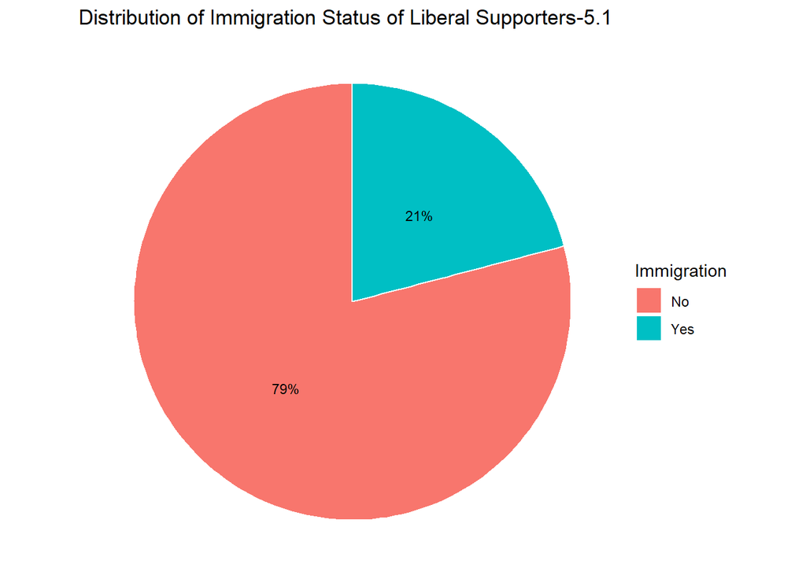

Figure 5.1 shows the percentage of immigrant population among Liberal supporters. The number of immigrants in Canada is 313.6 thousand in 2019, which is a small portion compared to the population in Canada. However, about one-fifth of Liberal supporters are immigrants according to the survey. Such a high proportion indicates how the Liberal’s ideology favors immigrants.

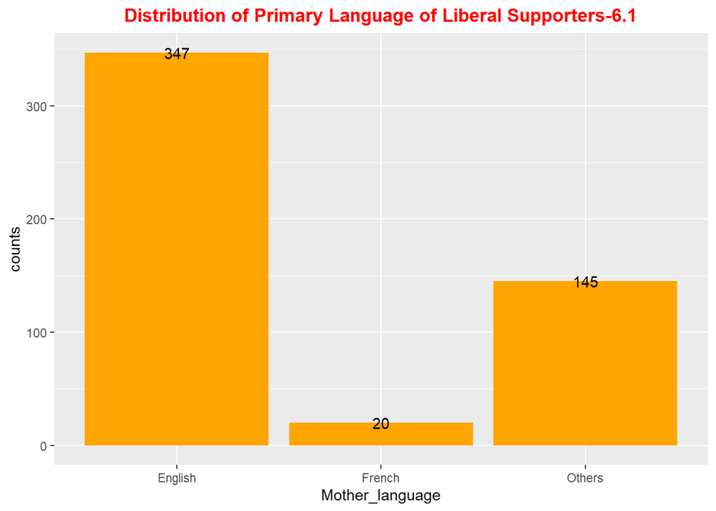

Figure 6.1 reflects that the anglophones are the absolute majority who support the Liberal Party. Contrarily, francophones count only 20 out of 512 valid votes. A considerable amount (145) of people who have other languages as primary languages favor the Liberal Party as well.

## Reference

https://www.elections.ca/res/rep/off/ovr2019app/home.html#17  
https://www150.statcan.gc.ca/n1/pub/89-503-x/2010001/article/11475-eng.htm  
https://www.elections.ca/content.aspx?section=res&dir=rec/part/estim/42ge&document=p1&lang=e#a  
https://www.statista.com/statistics/444858/canada-resident-population-by-gender-and-age-group/  
https://www12.statcan.gc.ca/census-recensement/2016/dp-pd/dv-vd/inc-rev/index-eng.cfm  
https://www.statista.com/statistics/484838/income-distribution-in-canada-by-income-level/  
https://www.statista.com/statistics/606823/population-of-ontario-by-educational-attainment/  
https://www12.statcan.gc.ca/census-recensement/2016/as-sa/fogs-spg/Facts-can-eng.cfm?Lang=Eng&GK=CAN&GC=01&TOPIC=7  
https://www.fin.gov.on.ca/en/economy/demographics/census/cenhi16-6.html